# BaP in RTD teas: Probabilistic Health Risk Assessment for Taiwanese consumers

Truong Ngan Giang

2025-10-11

## Summary

This analysis estimates the Margin of Exposure (MOE) for Benzo[a]pyrene (BaP) exposure from ready-to-drink tea consumption in Taiwanese population subgroups using Monte Carlo simulation.

**Key finding:** MOE results unequivocally indicate low health risk from daily RTD tea consumption across all demographic groups, from least to most exposed consumers.

## 1. Introduction

Benzo[a]pyrene is a polycyclic aromatic hydrocarbon (PAH) formed during food processing, particularly in grilled or smoked foods. The European Food Safety Authority (EFSA) established a Benchmark Dose Lower Confidence Limit (BMDL10) of 0.07 mg/kg bw/day for BaP. The Margin of Exposure (MOE) is calculated as: MOE = BMDL10/EDI with EDI = BaP concentrations x Consumption rate/ Body Weight

EFSA considers MOE values above 10,000 as of low concern for public health and risk managers (EFSA, 2005). For a conservative estimation, upper-bound estimates were used in a probabilistic Monte Carlo model. MOE values are presented as the 2.5th, 50th (median), and 97.5th percentiles for each demographic group, where: - **2.5th percentile:** Most vulnerable consumers (upper bound of exposure) - **50th percentile:** Average consumers - **97.5th percentile:** Least exposed consumers

## 2. Methods

### 2.1 Data Sources

- **Tea consumption and body weight:** Taiwan Food and Drug Administration (TFDA) national surveys (2017-2020)
- **BaP concentrations:** 51 tea samples analyzed for BaP content using a validated HPLC-FLD methods
- **Risk assessment parameter:** EFSA BMDL10 value (2008)

### 2.2 Monte Carlo Simulation

A 10,000-iteration Monte Carlo simulation was performed assuming lognormal distributions for all input variables. The simulation propagates uncertainty through the exposure assessment:

```r
# Population group data
bap_profiles <- data.frame(
  group = c("Male_0_3", "Male_3_6", "Male_6_12", "Male_12_16", "Male_16_18", "Male_19_65",
            "Female_0_3", "Female_3_6", "Female_6_12","Female_12_16", "Female_16_18", "Female_19_65"),
  # Tea consumption data (g/day)
  meanTea = c(158.47, 225.05, 376.35, 524.73, 556.15, 843.99,
              126.63, 172.28, 305.67, 379.94, 461.17, 565.50),
  sdTea = c(116.96, 173.68, 236.96, 346.89, 408.43, 836.87,
            91.73, 154.33, 228.84, 256.29, 345.76, 580.28),
  # Body weight data (kg)
  meanW = c(13.46, 20.52, 37.91, 61.75, 67.12, 73.19,
            12.27, 19.59, 35.18, 53.45, 58.11, 59.97),
  sdW = c(3.27, 5.04, 13.37, 16.31, 14.19, 14.29,
          3.01, 4.51, 11.98, 11.91, 13.99, 11.68)
)

# BaP concentration data (μg/kg): For a conservative estimation, the upper-bound estimates were used for assessment. Upper-bound estimates assume that the amounts in non-detected/non-quantified samples are equal Limit of Detection/Limit of Quantitation.
meanbap <- 0.128
sdbap <- 0.077

# Display data summary
knitr::kable(bap_profiles,
             caption = "Table 1: Population group characteristics from TFDA surveys",
             col.names = c("Group", "Mean Tea (g/day)", "SD Tea", "Mean BW (kg)", "SD BW"))
```

Table 1: Population group characteristics from TFDA surveys

| Group | Mean Tea (g/day) | SD Tea | Mean BW (kg) | SD BW |
| --- | --- | --- | --- | --- |
| Male_0_3 | 158.47 | 116.96 | 13.46 | 3.27 |
| Male_3_6 | 225.05 | 173.68 | 20.52 | 5.04 |
| Male_6_12 | 376.35 | 236.96 | 37.91 | 13.37 |
| Male_12_16 | 524.73 | 346.89 | 61.75 | 16.31 |
| Male_16_18 | 556.15 | 408.43 | 67.12 | 14.19 |
| Male_19_65 | 843.99 | 836.87 | 73.19 | 14.29 |
| Female_0_3 | 126.63 | 91.73 | 12.27 | 3.01 |
| Female_3_6 | 172.28 | 154.33 | 19.59 | 4.51 |
| Female_6_12 | 305.67 | 228.84 | 35.18 | 11.98 |
| Female_12_16 | 379.94 | 256.29 | 53.45 | 11.91 |
| Female_16_18 | 461.17 | 345.76 | 58.11 | 13.99 |
| Female_19_65 | 565.50 | 580.28 | 59.97 | 11.68 |

### 2.3 Simulation Code

```r
# Monte Carlo simulation
n_iter <- 10000
bap_results <- data.frame()

set.seed(123)

for (i in 1:nrow(bap_profiles)) {
  # Extract parameters for current group
  meanTea <- bap_profiles$meanTea[i]
  sdTea <- bap_profiles$sdTea[i]
  meanW <- bap_profiles$meanW[i]
  sdW <- bap_profiles$sdW[i]
  group <- bap_profiles$group[i]

  # Simulate tea consumption (lognormal)
  simTea <- rlnorm(n_iter,
                   meanlog = log(meanTea^2 / sqrt(sdTea^2 + meanTea^2)),
                   sdlog = sqrt(log(1 + (sdTea^2 / meanTea^2)))) / 1000

  # Simulate body weight (lognormal)
  simW <- rlnorm(n_iter,
                 meanlog = log(meanW^2 / sqrt(sdW^2 + meanW^2)),
                 sdlog = sqrt(log(1 + (sdW^2 / meanW^2))))

  # Simulate BaP concentration (lognormal, μg/kg)
  simbap <- rlnorm(n_iter,
                   meanlog = log(meanbap^2 / sqrt(sdbap^2 + meanbap^2)),
                   sdlog = sqrt(log(1 + (sdbap^2 / meanbap^2))))

  # Calculate daily intake and MOE
  DI <- (simbap * simTea) / simW  # μg/kg bw/day
  MOE <- 0.07 * 1000 / DI  # Convert BMDL10 from mg to μg

  # Store percentiles
  q <- quantile(MOE, probs = c(0.025, 0.5, 0.975))
  bap_results <- rbind(bap_results, data.frame(group = group,
                                       p2.5 = q[1],
                                       p50 = q[2],
                                       p97.5 = q[3]))
}

rownames(bap_results) <- NULL
```

## 3. Results

### 3.1 MOE Estimates by Population Group

```r
# Display results
knitr::kable(bap_results,
             digits = 0,
             col.names = c("Population Group",
                          "2.5th Percentile",
                          "Median (50th)",
                          "97.5th Percentile"),
             caption = "Table 2: Margin of Exposure (MOE) estimates")
```

Table 2: Margin of Exposure (MOE) estimates

| Population Group | 2.5th Percentile | Median (50th) | 97.5th Percentile |
| --- | --- | --- | --- |
| Male_0_3 | 10947 | 66375 | 379753 |
| Male_3_6 | 11827 | 71244 | 429182 |
| Male_6_12 | 13122 | 71506 | 385147 |
| Male_12_16 | 15973 | 88196 | 457505 |
| Male_16_18 | 15942 | 94944 | 536512 |
| Male_19_65 | 10188 | 74351 | 548361 |
| Female_0_3 | 12528 | 74352 | 431143 |
| Female_3_6 | 13221 | 93600 | 628982 |
| Female_6_12 | 13792 | 87223 | 546455 |
| Female_12_16 | 20440 | 105630 | 545770 |
| Female_16_18 | 16673 | 98178 | 603835 |
| Female_19_65 | 12509 | 95588 | 765466 |

**Interpretation:** For all age and gender groups, MOE values exceeded the safety threshold of 10,000, even for the most vulnerable consumers (2.5th percentile). The average consumer groups showed MOE values ranging from 66,375 to 105,630, while the least exposed groups showed values from 379,753 to 765,466; which is substantially higher than the safety threshold.

### 3.2 Visualization

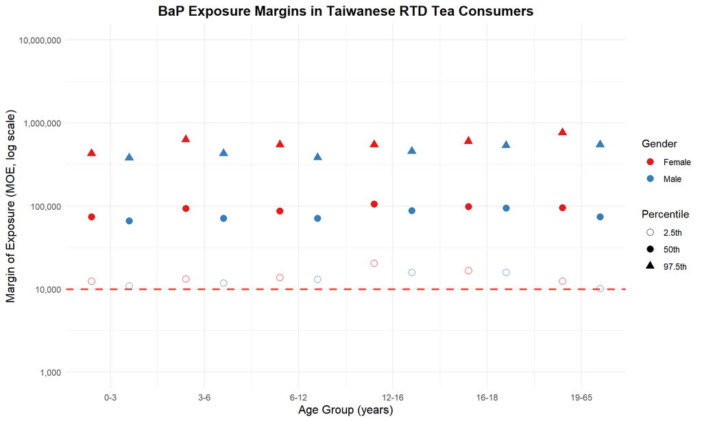

Figure 1: Margin of Exposure (MOE) by population group. Red dashed line indicates safety threshold (MOE = 10,000).

```r
# Prepare data for visualization
data_long <- bap_results %>%
  separate(group, into = c("Gender", "Age_Group"), sep = "_") %>%
  pivot_longer(
    cols = c(p2.5, p50, p97.5),
    names_to = "Percentile",
    values_to = "MOE"
  ) %>%
  mutate(
    Gender = factor(Gender, levels = c("Female", "Male")),
    Percentile = recode(Percentile,
                        "p2.5" = "2.5th",
                        "p50" = "50th",
                        "p97.5" = "97.5th"),
    Age_Group = factor(Age_Group, levels = unique(Age_Group)),
    Position = as.numeric(Age_Group) + ifelse(Gender == "Female", -0.2, 0.2)
  )

# Create plot
ggplot(data_long, aes(x = Position, y = MOE)) +
  geom_hline(yintercept = 10000, linetype = "dashed",
             color = "red", linewidth = 1, alpha = 0.7) +
  geom_point(aes(shape = Percentile, color = Gender), size = 3) +
  scale_shape_manual(values = c("2.5th" = 1, "50th" = 16, "97.5th" = 17)) +
  scale_color_manual(values = c("Female" = "#E41A1C", "Male" = "#377EB8")) +
  scale_y_log10(
    breaks = 10^(3:7),
    labels = c("1,000", "10,000", "100,000", "1,000,000", "10,000,000"),
    limits = c(1000, 10^7)
  ) +
  scale_x_continuous(
    breaks = 1:6,
    labels = c("0-3", "3-6", "6-12", "12-16", "16-18", "19-65")
  ) +
  labs(
    title = "BaP Exposure Margins in Taiwanese RTD Tea Consumers",
    x = "Age Group (years)",
    y = "Margin of Exposure (MOE, log scale)",
    shape = "Percentile",
    color = "Gender"
  ) +
  theme_minimal() +
  theme(
    plot.title = element_text(hjust = 0.5, size = 14, face = "bold"),
    axis.title = element_text(size = 12)
  )
```

## References

1. European Food Safety Authority (EFSA). (2005). Opinion of the Scientific Committee on a request from EFSA related to a harmonised approach for risk assessment of substances which are both genotoxic and carcinogenic. EFSA Journal, 3(10), 282.https://doi.org/10.2903/j.efsa.2005.282
2. European Food Safety Authority (EFSA). Polycyclic aromatic hydrocarbons in food - Scientific opinion of the Panel on Contaminants in the Food Chain. EFSA Journal, 6(8), 724. https://doi.org/10.2903/j.efsa.2008.724
3. GEMS / Food-EURO Second Workshop on Reliable Evaluation of Low-Level Contamination of food Report on a workshop in the frame of GEMS / Food-EURO Kulmbach. (1999). https://www.semanticscholar.org/paper/GEMS-Food-EURO-Second-Workshop-on-Reliable-of-of-on/7d5162794a407ce3361458649750a63b6bda3381
4. Joint, F. A. O. (2005). Joint FAO/WHO Expert. Committee on Food Additives Sixty-Fourth Meeting, Rome, 8–17 February 2005. World Health Organization: Geneva, Switzerland. https://openknowledge.fao.org/handle/20.500.14283/at877e
5. Taiwan Food and Drug Administration & National Institutes of Health. (2020). Calculation results of consumer-only food item intake (2017-2020 Nutrition Survey). In National Food Intake Database. https://tnfcds.nhri.edu.tw/